# Artículo 3: GhostBusters

## Procesamiento de los datos

Los relatos fueron organizados en un corpus con identificador único. Se aplicó tokenización y se eliminaron stopwords en inglés, números y duplicados. Para reducir ruido se crearon variaciones con las palabras con frecuencia mayor a 10 y, adicionalmente, se construyó una versión reducida con las 800 palabras más frecuentes por frecuencia documental (DF). Se generaron matrices documento–término dispersas y se calcularon variables emocionales NRC (ira, miedo, tristeza, sorpresa, confianza, etc.) como rasgos adicionales.

## Clasificador Naive Bayes

El modelo Naive Bayes es un clasificador probabilístico inspirado en el teorema de Bayes, que establece la relación entre la probabilidad a priori y la probabilidad condicional de una clase $C$ dado un conjunto de atributos $X = (x_1, x_2, \dots, x_n)$:

$$P(C \mid X) = \frac{P(X \mid C) \, P(C)}{P(X)}$$

En el contexto de clasificación, el denominador $P(X)$ es común a todas las clases, por lo que la decisión se basa en maximizar la probabilidad posterior:

$$\hat{C} = \arg \max_{C} \; P(C) \prod_{i=1}^n P(x_i \mid C)$$

### Independencia condicional y estructura de red

El adjetivo naive (ingenuo) proviene de la suposición de independencia condicional: se asume que cada atributo $x_i$ es independiente de los demás atributos dado el conocimiento de la clase $C$.

En términos de redes bayesianas, esto equivale a un grafo dirigido acíclico donde la clase $C$ es el nodo padre y cada atributo $x_i$ es un nodo hijo condicionado únicamente por C. No se consideran aristas entre atributos, lo cual simplifica enormemente el cálculo de la distribución conjunta:

$$P(x_1, x_2, \dots, x_n \mid C) = \prod_{i=1}^n P(x_i \mid C)$$
(Murphy, 2012; Mitchell, 1997; Manning et al., 2008)

### Variedades del modelo

Dependiendo de la naturaleza de los atributos, el modelo puede adoptar distintas distribuciones de probabilidad: • Multinomial Naive Bayes: adecuado para representaciones de texto en forma de conteos (BOW (Bag of Words), frecuencia de términos). Cada atributo sigue una distribución multinomial condicionada a la clase. • Bernoulli Naive Bayes: usa variables binarias (presencia/ausencia de una palabra). • Gaussian Naive Bayes: asume que los atributos numéricos siguen una distribución normal condicionada a la clase. Es aquí donde se habla de una red bayesiana gaussiana ingenua, donde cada nodo hijo tiene como distribución una Gaussiana dependiente del nodo padre (la clase). • Poisson Naive Bayes: diseñado para variables de conteo, modelando $P(x_i \mid C)$ como una distribución de Poisson.

### Interpretación en clasificación de texto

En nuestro caso, al trabajar con una matriz documento–término, cada término $x_i$ representa la frecuencia (o presencia) de una palabra en un relato. La hipótesis ingenua permite calcular de manera eficiente la probabilidad de un relato dado que pertenece a una categoría paranormal $C$, incluso cuando el número de atributos (palabras) supera los miles.

A pesar de que la suposición de independencia rara vez se cumple estrictamente en lenguaje natural (pues las palabras están correlacionadas), en la práctica Naive Bayes funciona sorprendentemente bien debido a que: 1. El modelo captura regularidades robustas en las distribuciones de palabras por clase. 2. La clasificación solo requiere identificar la clase más probable, no estimar probabilidades exactas. 3. El suavizado de Laplace evita que términos poco frecuentes asignen probabilidad cero, lo que estabiliza la clasificación.

## Modelos e Implementaciones

Se entrenaron y evaluaron cinco configuraciones principales de características: 1. BOW (Bag of Words/Todas las palabras) completo. 2. BOW reducido (Top-800 términos). 3. Solo NRC. 4. BOW completo + NRC. 5. BOW reducido + NRC.

Se probaron estas 5 variaciones en cada una de las siguientes implementaciones.

### 1. Librería e1071::naiveBayes (baseline)

```
•   Qué hace: Implementa un Naive Bayes clásico mixto:
•   Para variables numéricas asume verosimilitud Gaussiana por clase
```

$x_i \mid C=c \sim \mathcal{N}(\mu_{ic}, \sigma_{ic}^2)$. • Para variables categóricas usa tablas de probabilidad por clase (multinomial/bernoulli implícito). • Suavizamiento de Laplace (laplace): evita ceros en las tablas categóricas sumando $\alpha$ pseudo-conteos: $\hat p = \frac{n + \alpha}{N + \alpha K}$. En texto (BOW), esto reduce el “cero fatal” cuando una palabra nunca apareció en la clase durante el entrenamiento. • Limitaciones relevantes: No modela explícitamente conteos como Poisson; a las columnas numéricas (conteos) las trata como si fueran gaussianas, lo que a veces funciona bien pero no es lo más natural para datos dispersos de conteo.

### 2. naivebayes::naive_bayes (con y sin Poisson)

```
•   Qué aporta: Misma lógica Bayes ingenuo, pero con implementaciones muy eficientes y opción de modelar conteos con Poisson vía usepoisson = TRUE:
```

$x_i \mid C=c \sim \text{Poisson}(\lambda_{ic})$, $\quad\mathbb{P}(x_i=k\mid C=c)=e^{-\lambda_{ic}}\frac{\lambda_{ic}^k}{k!}$.

Esto es particularmente razonable para matrices documento-término (conteos por palabra). • Modos de verosimilitud: • Sin Poisson: numéricas ~ Gaussian, binarias ~ Bernoulli, categóricas ~ Categorical; con laplace para suavizar. • Con Poisson: columnas numéricas se modelan como conteos; mantiene laplace para evitar ceros en partes categóricas. • Ventaja práctica: suele ser más estable/rápido con muchas columnas y permite comparar directamente si Poisson mejora frente al supuesto Gaussiano sobre los conteos.

### 3. Librería e1071::naiveBayes con búsqueda de Laplace mediante cross-validation (CV)

```
•   Motivación: El valor de $\alpha$ (Laplace smoothing) afecta fuertemente la probabilidad posterior, sobre todo cuando el vocabulario es grande y disperso.
•   Cómo lo hicimos: K-fold CV sólo en el conjunto de entrenamiento, evaluando una pequeña grilla $\alpha \in \{0, 0.5, 1, 2, 3\}$. Seleccionamos el $\alpha$ que maximiza accuracy (o F1-macro) promedio en validación y reentrenamos con ese valor antes de evaluar en test.
•   Detalle importante: Para evitar errores numéricos, filtramos columnas constantes (varianza cero) por clase en el train; así nos aseguramos de que las verosimilitudes estén bien definidas en todos los folds.
```

En las 3 implementaciones, con sus 5 diferentes pruebas, se usaron funciones para agilizar el proceso de entrenamiento y predicción.

# Aplicación y Resultados

## Resultados con `e1071`

La librería **e1071** se probó con cinco configuraciones: Bag of Words (BOW) completo, BOW Top-800, NRC solo y las combinaciones BOW + NRC.  
Los mejores resultados se obtuvieron con **BOW Top-800**, alcanzando un *accuracy* de **0.7716**, *precision* de **0.8178**, *recall* de **0.7231** y un *F1-score* de **0.7675**.  
Este modelo logra un buen equilibrio entre precisión y sensibilidad, superando al BOW completo (que aunque tiene alta precisión, muestra un *recall* muy bajo).

| accuracy | precision | recall | f1_score | modelo |
| --- | --- | --- | --- | --- |
| 0.7716 | 0.8178 | 0.7231 | 0.7675 | BOW Top-800 (e1071) |
| 0.7716 | 0.8178 | 0.7231 | 0.7675 | BOW Top-800 + NRC (e1071) |
| 0.6487 | 0.9158 | 0.3595 | 0.5163 | BOW completo (e1071) |
| 0.6487 | 0.9158 | 0.3595 | 0.5163 | BOW completo + NRC (e1071) |
| 0.5539 | 0.6522 | 0.3099 | 0.4202 | NRC solo (e1071) |

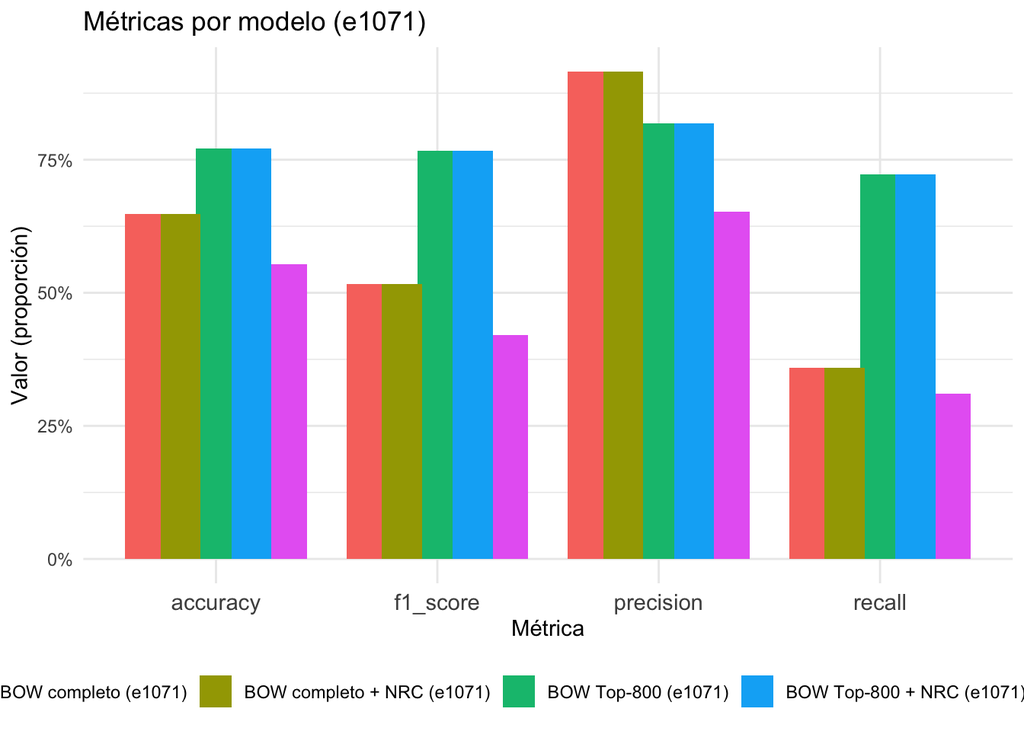

La siguiente figura muestra la matriz de confusión para este caso:

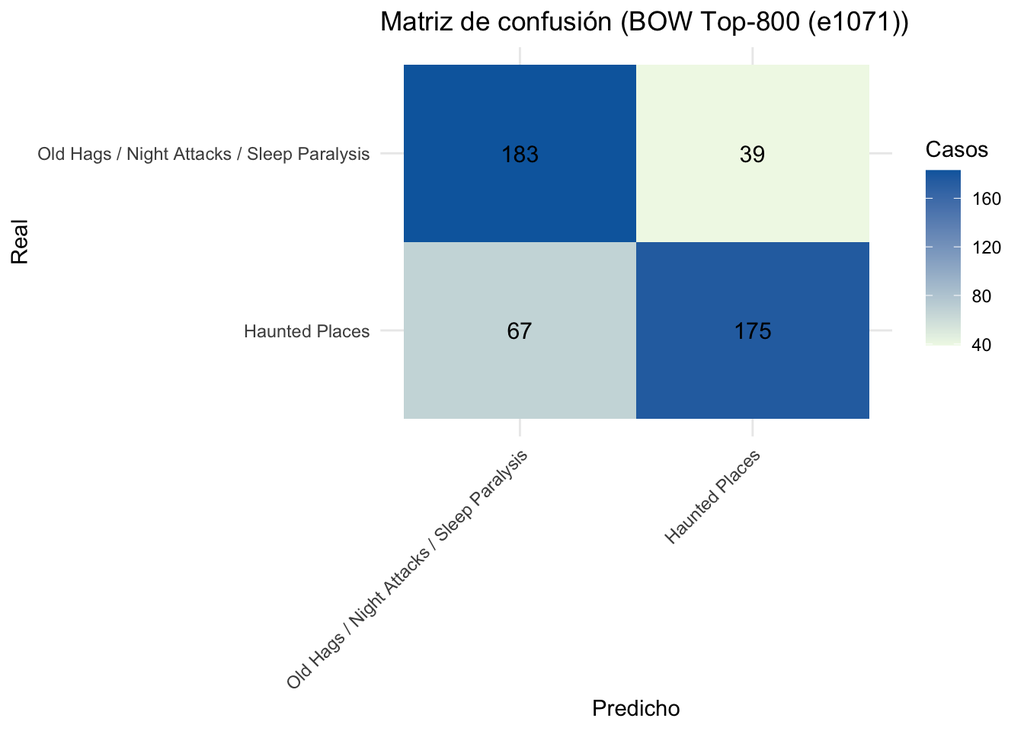

## Resultados con naivebayes

La librería naivebayes permitió comparar el desempeño de los modelos con y sin Poisson. Se replicaron las mismas cinco configuraciones (BOW completo, BOW Top-800, NRC solo, y sus combinaciones).

Los resultados muestran que la elección de Poisson no alteró significativamente las métricas en este dataset: los valores de accuracy, precision, recall y F1-score fueron prácticamente iguales con y sin Poisson. El mejor desempeño se observó nuevamente con BOW Top-800, alcanzando métricas muy similares a las de e1071.

| modelo | poisson | accuracy | precision | recall | f1_score |
| --- | --- | --- | --- | --- | --- |
| BOW Top-800 | Sin Poisson | 0.7716 | 0.8178 | 0.7231 | 0.7675 |
| BOW Top-800 | Con Poisson | 0.7716 | 0.8178 | 0.7231 | 0.7675 |
| BOW Top-800 + NRC | Sin Poisson | 0.7672 | 0.8131 | 0.7190 | 0.7632 |
| BOW Top-800 + NRC | Con Poisson | 0.7672 | 0.8131 | 0.7190 | 0.7632 |
| BOW completo | Sin Poisson | 0.6487 | 0.9158 | 0.3595 | 0.5163 |
| BOW completo | Con Poisson | 0.6487 | 0.9158 | 0.3595 | 0.5163 |
| BOW completo + NRC | Sin Poisson | 0.6487 | 0.9158 | 0.3595 | 0.5163 |
| BOW completo + NRC | Con Poisson | 0.6487 | 0.9158 | 0.3595 | 0.5163 |
| NRC solo | Sin Poisson | 0.5539 | 0.6522 | 0.3099 | 0.4202 |
| NRC solo | Con Poisson | 0.5539 | 0.6522 | 0.3099 | 0.4202 |

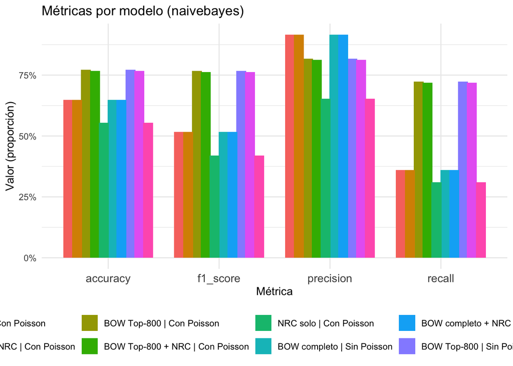

[figure not shown]

## Resultados con Cross-Validation de Laplace (e1071)

Finalmente, se implementó validación cruzada (CV) para seleccionar el parámetro de Laplace smoothing. Curiosamente, en todos los casos la CV seleccionó laplace = 0, lo que significa que el suavizado no aportó mejoras en este conjunto de datos.

El mejor resultado se dio con el BOW completo, logrando un accuracy de 0.7845, precision de 0.8413, recall de 0.7231 y F1-score de 0.7778, ligeramente superior a los demás modelos.

| dataset | laplace | accuracy | precision | recall | f1_score |
| --- | --- | --- | --- | --- | --- |
| BOW completo | 0 | 0.7845 | 0.8413 | 0.7231 | 0.7778 |
| BOW Top-800 | 0 | 0.7716 | 0.8178 | 0.7231 | 0.7675 |
| NRC solo | 0 | 0.5539 | 0.6522 | 0.3099 | 0.4202 |
| BOW completo + NRC | 0 | 0.7845 | 0.8413 | 0.7231 | 0.7778 |
| BOW Top-800 + NRC | 0 | 0.7694 | 0.8169 | 0.7190 | 0.7648 |

| dataset | laplace | metric | value |
| --- | --- | --- | --- |
| BOW completo | 0 | accuracy | 0.7845 |
| BOW completo | 0 | precision | 0.8413 |
| BOW completo | 0 | recall | 0.7231 |
| BOW completo | 0 | f1_score | 0.7778 |
| BOW Top-800 | 0 | accuracy | 0.7716 |
| BOW Top-800 | 0 | precision | 0.8178 |
| BOW Top-800 | 0 | recall | 0.7231 |
| BOW Top-800 | 0 | f1_score | 0.7675 |
| NRC solo | 0 | accuracy | 0.5539 |
| NRC solo | 0 | precision | 0.6522 |
| NRC solo | 0 | recall | 0.3099 |
| NRC solo | 0 | f1_score | 0.4202 |
| BOW completo + NRC | 0 | accuracy | 0.7845 |
| BOW completo + NRC | 0 | precision | 0.8413 |
| BOW completo + NRC | 0 | recall | 0.7231 |
| BOW completo + NRC | 0 | f1_score | 0.7778 |
| BOW Top-800 + NRC | 0 | accuracy | 0.7694 |
| BOW Top-800 + NRC | 0 | precision | 0.8169 |
| BOW Top-800 + NRC | 0 | recall | 0.7190 |
| BOW Top-800 + NRC | 0 | f1_score | 0.7648 |

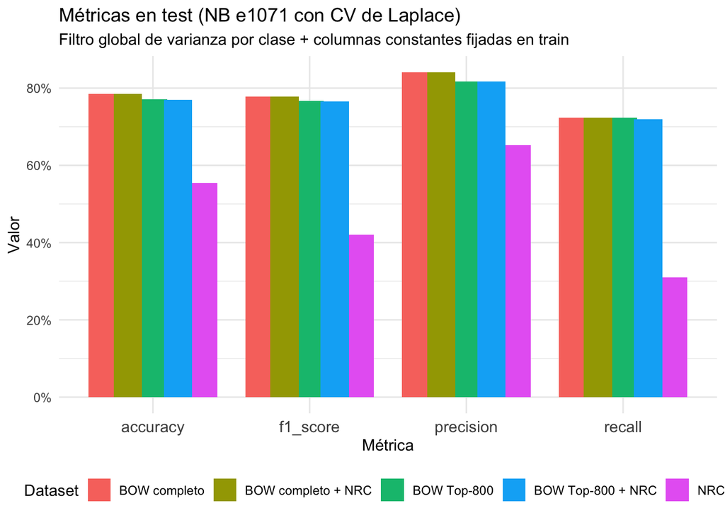

A continuación se muestra su matriz de confusión:

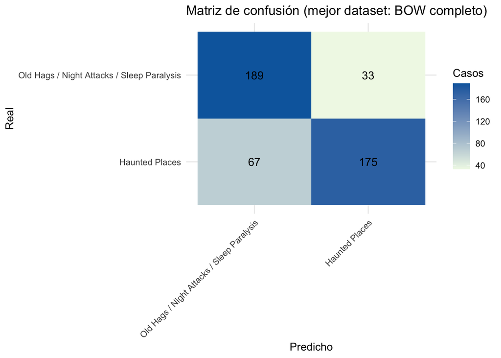

# Conclusiones

```
•   En la librería e1071, el mejor modelo fue BOW Top-800, destacando por su equilibrio entre precisión y recall.
•   Con la librería naivebayes, no se observaron diferencias entre los modelos con y sin Poisson; el mejor desempeño también se obtuvo con BOW Top-800.
•   La validación cruzada de Laplace reveló que el mejor valor era laplace = 0, con un desempeño superior en el BOW completo, alcanzando el mayor accuracy y F1-score de todos los experimentos.
```

En resumen, los resultados muestran que la reducción de vocabulario (Top-800) mejora el balance precisión-sensibilidad, pero la combinación con CV y Laplace favorece al modelo con BOW completo. Para futuras implementaciones, sería recomendable: 1. Probar representaciones alternativas como TF-IDF para resaltar términos distintivos. 2. Incorporar más rasgos semánticos (emociones NRC extendidas, longitud de texto, etc.). 3. Evaluar modelos más flexibles como regresión logística regularizada o SVM para comparar con Naive Bayes.

# Referencias

- Manning, C. D., Raghavan, P., & Schütze, H. (2008). Introduction to Information Retrieval. Cambridge University Press.
- Mitchell, T. M. (1997). Machine Learning. McGraw-Hill.
- Murphy, K. P. (2012). Machine Learning: A Probabilistic Perspective. MIT Press.
- Çetinkaya-Rundel, M. (2024, octubre 1). Web scraping [Presentación]. Duke University, STA 199 – Fall 2024.